# The Analytics Edge - Unit 5 : Text Analytics on Enron Emails

Reproducible notes following lecture slides and videos

Giovanni Fossati

[ [source files available on GitHub](https://github.com/pedrosan/TheAnalyticsEdge) ]

## PRELIMINARIES

Libraries needed for data processing and plotting:

```r
library("tm")
library("SnowballC")

library("caTools")
library("rpart")
library("rpart.plot")
library("ROCR")
```

## INTRODUCTION

We will be looking into how to use the text of emails in the inboxes of Enron executives to predict if those emails are relevant to an investigation into the company.

We will be extracting word frequencies from the text of the documents, and then integrating those frequencies into predictive models.

We are going to talk about **predictive coding** – an emerging use of text analytics in the area of criminal justice.

The case we will consider concerns Enron, a US energy company based out of Houston, Texas that was involved in a number of electricity production and distribution markets and that collapsed in the early 2000’s after widespread account fraud was exposed. To date Enron remains a stunning symbol of corporate corruption.

While Enron’s collapse stemmed largely from accounting fraud, the firm also faced sanctions for its involvement in the California electricity crisis.  
In 2000 to 2001, California experienced a number of power blackouts, despite having sufficient generating capacity.  
It later surfaced that Enron played a key role in this energy crisis by artificially reducing power supply to spike prices and then making a profit from this market instability.

The *Federal Energy Regulatory Commission*, or *FERC*, investigated Enron’s involvement in the crisis, and its investigation eventually led to a $1.52 billion settlement.  
FERC’s investigation into Enron will be the topic of today’s recitation.

### The *eDiscovery* Problem

Enron was a huge company, and its corporate servers contained millions of emails and other electronic files. Sifting through these documents to find the ones relevant to an investigation is no simple task.

In law, this electronic document retrieval process is called the **eDiscovery problem**, and **relevant files** are called **responsive documents**.  
Traditionally, the eDiscovery problem has been solved by using keyword search. In our case, perhaps, searching for phrases like “*electricity bid*” or “*energy schedule*”, followed by an expensive and time-consuming manual review process, in which attorneys read through thousands of documents to determine which ones are responsive.

### Predictive Coding

**Predictive coding** is a new technique in which attorneys manually label some documents and then use text analytics models trained on the manually labeled documents to predict which of the remaining documents are responsive.

### The Data

As part of its investigation, the *FERC* released hundreds of thousands of emails from top executives at Enron creating the **largest publicly available set of emails today**.  
We will use this data set called the *Enron Corpus* to perform predictive coding in this recitation.

The data set contains just two fields:

- **email**: the text of the email in question,
- **responsive**: a binary (0/1) variable telling whether the email relates to energy schedules or bids.

The labels for these emails were made by attorneys as part of the 2010 text retrieval conference legal track, a predictive coding competition.

## LOADING THE DATA

```r
emails <- read.csv("data/energy_bids.csv.gz", stringsAsFactors = FALSE)
```

```r
str(emails)
```

```
## 'data.frame':    855 obs. of  2 variables:
##  $ email     : chr  "North America's integrated electricity market requires cooperation on environmental policies Commission for Environmental Coope"| __truncated__ "FYI -----Original Message----- From: \t\"Ginny Feliciano\" <gfeliciano@earthlink.net>@ENRON [mailto:IMCEANOTES-+22Ginny+20Felic"| _…
##  $ responsive: int  0 1 0 1 0 0 1 0 0 0 ...
```

Let’s look at a few examples (using the `strwrap()` function for easier-to-read formatting):

```r
strwrap(emails$email[1])
```

```
##  [1] "North America's integrated electricity market requires cooperation on environmental"
##  [2] "policies Commission for Environmental Cooperation releases working paper on North"
##  [3] "America's electricity market Montreal, 27 November 2001 -- The North American Commission"
##  [4] "for Environmental Cooperation (CEC) is releasing a working paper highlighting the trend"
##  [5] "towards increasing trade, competition and cross-border investment in electricity between"
##  [6] "Canada, Mexico and the United States. It is hoped that the working paper, Environmental"
##  [7] "Challenges and Opportunities in the Evolving North American Electricity Market, will"
##  [8] "stimulate public discussion around a CEC symposium of the same title about the need to"
##  [9] "coordinate environmental policies trinationally as a North America-wide electricity"
## [10] "market develops. The CEC symposium will take place in San Diego on 29-30 November, and"
## [11] "will bring together leading experts from industry, academia, NGOs and the governments of"
## [12] "Canada, Mexico and the United States to consider the impact of the evolving continental"
## [13] "electricity market on human health and the environment. \"Our goal [with the working paper"
## [14] "and the symposium] is to highlight key environmental issues that must be addressed as the"
## [15] "electricity markets in North America become more and more integrated,\" said Janine"
```

[output cut: 51 more lines]

We can see just by parsing through the first couple of lines that this is an email about a new working paper, “*The Environmental Challenges and Opportunities in the Evolving North American Electricity Market*”, released by the Commission for Environmental Cooperation, or CEC.  
While this certainly deals with electricity markets, it doesn’t have to do with energy schedules or bids, hence it is not *responsive* to our query. If we look at the value in the `responsive` variable for this email:

```r
emails$responsive[1]
```

```
## [1] 0
```

we see that its value is **0**, as expected.

Let’s check the second email:

```r
strwrap(emails$email[2])
```

```
##  [1] "FYI -----Original Message----- From: \"Ginny Feliciano\" <gfeliciano@earthlink.net>@ENRON"
##  [2] "[mailto:IMCEANOTES-+22Ginny+20Feliciano+22+20+3Cgfeliciano+40earthlink+2Enet+3E+40ENRON@ENRON.com]"
##  [3] "Sent: Thursday, June 28, 2001 3:40 PM To: Silvia Woodard; Paul Runci; Katrin Thomas; John"
##  [4] "A. Riggs; Kurt E. Yeager; Gregg Ward; Philip K. Verleger; Admiral Richard H. Truly; Susan"
##  [5] "Tomasky; Tsutomu Toichi; Susan F. Tierney; John A. Strom; Gerald M. Stokes; Kevin"
##  [6] "Stoffer; Edward M. Stern; Irwin M. Stelzer; Hoff Stauffer; Steven R. Spencer; Robert"
##  [7] "Smart; Bernie Schroeder; George A. Schreiber, Jr.; Robert N. Schock; James R."
##  [8] "Schlesinger; Roger W. Sant; John W. Rowe; James E. Rogers; John F. Riordan; James"
##  [9] "Ragland; Frank J. Puzio; Tony Prophet; Robert Priddle; Michael Price; John B. Phillips;"
## [10] "Robert Perciasepe; D. Louis Peoples; Robert Nordhaus; Walker Nolan; William A. Nitze;"
## [11] "Kazutoshi Muramatsu; Ernest J. Moniz; Nancy C. Mohn; Callum McCarthy; Thomas R. Mason;"
## [12] "Edward P. Martin; Jan W. Mares; James K. Malernee; S. David Freeman; Edwin Lupberger;"
## [13] "Amory B. Lovins; Lynn LeMaster; Hoesung Lee; Lay, Kenneth; Lester Lave; Wilfrid L. Kohl;"
## [14] "Soo Kyung Kim; Melanie Kenderdine; Paul L. Joskow; Ira H. Jolles; Frederick E. John; John"
## [15] "Jimison; William W. Hogan; Robert A. Hefner, III; James K. Gray; Craig G. Goodman;"
## [16] "Charles F. Goff, Jr.; Jerry D. Geist; Fritz Gautschi; Larry G. Garberding; Roger Gale;"
## [17] "William Fulkerson; Stephen E. Frank; George Frampton; Juan Eibenschutz; Theodore R. Eck;"
## [18] "Congressman John Dingell; Brian N. Dickie; William E. Dickenson; Etienne Deffarges;"
## [19] "Wilfried Czernie; Loren C. Cox; Anne Cleary; Bernard H. Cherry; Red Cavaney; Ralph"
## [20] "Cavanagh; Thomas R. Casten; Peter Bradford; Peter D. Blair; Ellen Berman; Roger A."
## [21] "Berliner; Michael L. Beatty; Vicky A. Bailey; Merribel S. Ayres; Catherine G. Abbott"
## [22] "Subject: Energy Deregulation - California State Auditor Report Attached is my report"
## [23] "prepared on behalf of the California State Auditor. I look forward to seeing you at The"
## [24] "Aspen Institute Energy Policy Forum. Charles J. Cicchetti Pacific Economics Group, LLC -"
## [25] "ca report new.pdf ***********"
```

The original message is actually very short, it just says *FYI*, and most of it is a forwarded message. We have the list of recipients, and down at the very bottom is the message itself. “Attached is my report prepared on behalf of the California State auditor.” There is also an attached report.  
Our data set contains just the text of the emails and not the text of the attachments. It turns out, as we might expect, that this attachment had to do with Enron’s electricity bids in California, and therefore this email is *responsive* to our query.  
We can check this in the value of the `responsive` variable.

```r
emails$responsive[2]
```

```
## [1] 1
```

We see that that it is a **1**.

Let’s look at the breakdown of the number of emails that are responsive to our query.

```r
table(emails$responsive)
```

```
##
##   0   1
## 716 139
```

We see that the data set is unbalanced, with a relatively small proportion of emails responsive to the query. This is typical in predictive coding problems.

## CREATING A CORPUS

```r
corpus <- Corpus(VectorSource(emails$email))
```

Let’s take a look at corpus:

```r
corpus
## <<VCorpus (documents: 855, metadata (corpus/indexed): 0/0)>>
```

### Converting text to *lower case*

We use the `tm_map()` function which takes as

- its first argument the name of a **corpus** and
- as second argument a **function performing the transformation** that we want to apply to the text.

To transform all text *to lower case*:

```r
corpus <- tm_map(corpus, tolower)
```

```r
corpus <- tm_map(corpus, PlainTextDocument)
```

### Removing punctuation

```r
corpus <- tm_map(corpus, removePunctuation)
```

### Removing *stop words*

Removing words can be done with the `removeWords` argument to the `tm_map()` function, with an extra argument, *i.e.* what the stop words are that we want to remove, for which we simply use the list for english that is provided by the `tm` package.

```r
corpus <- tm_map(corpus, removeWords, stopwords("english"))
```

### Stemming

Lastly, we want to stem our document with the `stemDocument` argument.

```r
corpus <- tm_map(corpus, stemDocument)
```

Now that we have gone through those four preprocessing steps, we can take a second look at the first email in the corpus.

```r
strwrap(corpus[[1]])
```

```
##  [1] "north america integr electr market requir cooper environment polici commiss environment"
##  [2] "cooper releas work paper north america electr market montreal 27 novemb 2001 north"
##  [3] "american commiss environment cooper cec releas work paper highlight trend toward increas"
##  [4] "trade competit crossbord invest electr canada mexico unit state hope work paper"
##  [5] "environment challeng opportun evolv north american electr market will stimul public"
##  [6] "discuss around cec symposium titl need coordin environment polici trinat north americawid"
##  [7] "electr market develop cec symposium will take place san diego 2930 novemb will bring"
##  [8] "togeth lead expert industri academia ngos govern canada mexico unit state consid impact"
##  [9] "evolv continent electr market human health environ goal work paper symposium highlight"
## [10] "key environment issu must address electr market north america becom integr said janin"
## [11] "ferretti execut director cec want stimul discuss around import polici question rais"
## [12] "countri can cooper approach energi environ cec intern organ creat environment side"
## [13] "agreement nafta known north american agreement environment cooper establish address"
## [14] "region environment concern help prevent potenti trade environment conflict promot effect"
## [15] "enforc environment law cec secretariat believ greater north american cooper environment"
```

[output cut: 29 more lines]

It looks quite a bit different now. It is a lot harder to read now that we removed all the stop words and punctuation and word stems, but now the emails in this corpus are ready for our machine learning algorithms.

## BAG OF WORDS

### Create a *Document Term Matrix*

The values in the matrix are the number of times that word appears in each document.

```r
DTM <- DocumentTermMatrix(corpus)
```

```r
DTM
## <<DocumentTermMatrix (documents: 855, terms: 21735)>>
## Non-/sparse entries: 102511/18480914
## Sparsity           : 99%
## Maximal term length: 113
## Weighting          : term frequency (tf)
```

what we can see is that even though we have only **855** emails in the corpus, we have over **21735** terms that showed up at least once, which is clearly too many variables for the number of observations we have.

So we want to remove the terms that don’t appear too often in our data set.

### Remove sparse terms

Therefore let’s remove some terms that don’t appear very often.

```r
sparse_DTM <- removeSparseTerms(DTM, 0.97)
```

Now we can take a look at the summary statistics for the document-term matrix:

```r
sparse_DTM
## <<DocumentTermMatrix (documents: 855, terms: 788)>>
## Non-/sparse entries: 51644/622096
## Sparsity           : 92%
## Maximal term length: 19
## Weighting          : term frequency (tf)
```

We can see that we have decreased the number of terms to **788**, which is a much more reasonable number.

### Creating a Data Frame from the *DTM*

Let’s convert the sparse matrix into a data frame that we will be able to use for our predictive models.

```r
labeledTerms <- as.data.frame(as.matrix(sparse_DTM))
```

To make all variable names *R-friendly* use:

```r
colnames(labeledTerms) <- make.names(colnames(labeledTerms))
```

We also have to add back-in the outcome variable

```r
labeledTerms$responsive <- emails$responsive
```

```r
# str(labeledTerms)
```

The data frame contains an awful lot of variables, **789** in total, of which **788** are the frequencies of various words in the emails, and the last one is `responsive`, *i.e.* the outcome variable.

### Split data in training/testing sets

Lastly, let’s split our data into a training set and a testing set, putting **70%** of the data in the **training** set.

```r
set.seed(144)

split <- sample.split(labeledTerms$responsive, SplitRatio = 0.7)

train <- subset(labeledTerms, split == TRUE)
test <- subset(labeledTerms, split == FALSE)
```

## BUILD A CART MODEL

Now we are ready to build the model, and we will build a simple *CART model* using the **default parameters**. A random forest would be another good choice from our toolset.

```r
emailCART <- rpart(responsive ~ . , data = train, method = "class")
```

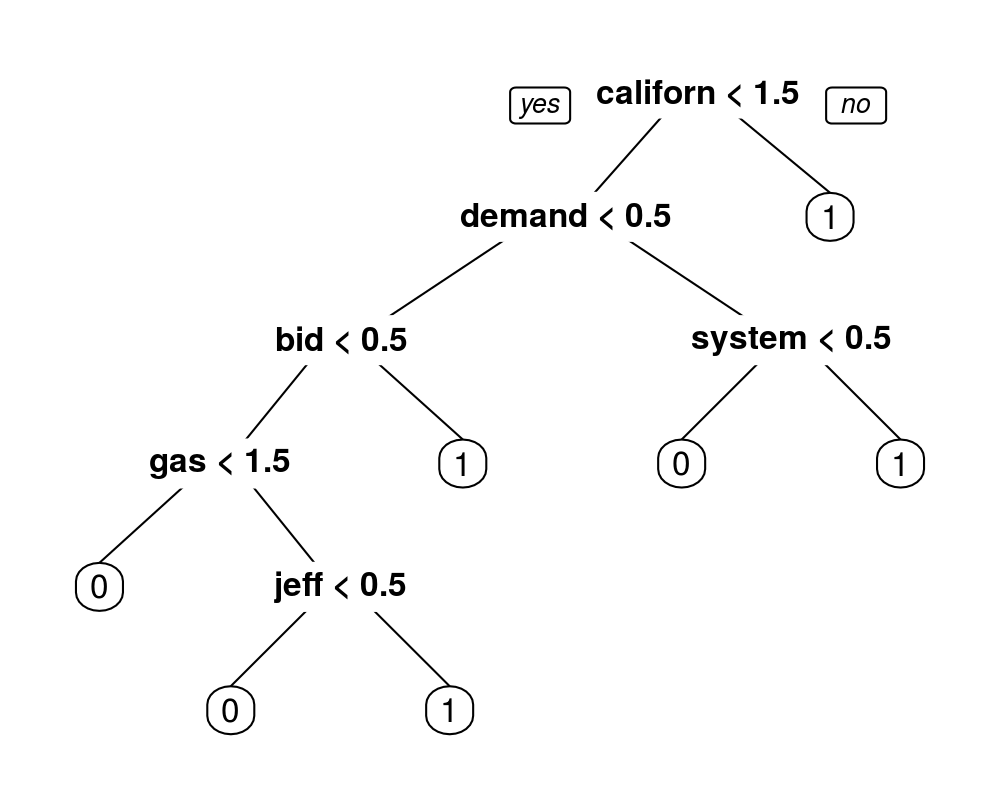

```r
prp(emailCART)
```

We see at the very top is the word *California*.

- If `californ` appears at least twice in an email, we are going to take the right path and predict that a document is **responsive**.  
  It is somewhat unsurprising that California shows up, because we know that Enron had a heavy involvement in the California energy markets.
- Further down the tree, we see a number of other terms that we could plausibly expect to be related to energy bids and energy scheduling, like `system`, `demand`, `bid`, and `gas`.
- Down at the bottom is `jeff`, which is perhaps a reference to Enron’s CEO, Jeff Skillings, who ended up actually being jailed for his involvement in the fraud at the company.

### Out-of-Sample Performance of the Model

Now that we have trained a model, we need to evaluate it on the test set.  
We build an object `predictCART` that has the predicted probabilities for each class from our CART model, by using the `predict()` function on the model `emailCART` and the test data with `newdata = test`.

```r
predictCART <- predict(emailCART, newdata = test)
```

This new object gives us the predicted probabilities on the test set. We can look at the first 10 rows with

```r
predictCART[1:10, ]
```

```
##                        0          1
## character(0)   0.2156863 0.78431373
## character(0).1 0.9557522 0.04424779
## character(0).2 0.9557522 0.04424779
## character(0).3 0.8125000 0.18750000
## character(0).4 0.4000000 0.60000000
## character(0).5 0.9557522 0.04424779
## character(0).6 0.9557522 0.04424779
## character(0).7 0.9557522 0.04424779
## character(0).8 0.1250000 0.87500000
## character(0).9 0.1250000 0.87500000
```

- The **first** column is the predicted probability of the document being **non-responsive**.
- The **second** column is the predicted probability of the document being **responsive**.
- They sum to 1.

In our case we are interested in the predicted probability of the document being responsive and it would be convenient to handle that as a separated variable.

```r
predictCART.prob <- predictCART[ , 2]
```

This new object contains our test set predicted probabilities.

We are interested in the **accuracy** of our model on the test set, *i.e.* out-of-sample. First we compute the *confusion matrix*:

```r
cmat_CART <- table(test$responsive, predictCART.prob >= 0.5)
cmat_CART
```

```
##
##     FALSE TRUE
##   0   195   20
##   1    17   25
```

```r
accu_CART <- (cmat_CART[1,1] + cmat_CART[2,2])/sum(cmat_CART)
```

- **Overall accuracy** of this *CART* model is **0.856**
- **Sensitivity** = **TP rate** = 25 / 42 = **0.595**
- **Specificity** = **(1 - FP rate)** = 195 / 215 = **0.907**
- **FP rate** = 20 / 215 = **0.093**
- **FN rate** = 17 / 42 = **0.405**

### Comparison with the *baseline model*

Let’s compare this to a simple baseline model that **always predicts non-responsive** (*i.e.* the most common value of the dependent variable).  
To compute the accuracy of the baseline model, let’s make a table of just the outcome variable `responsive`.

```r
cmat_baseline <- table(test$responsive)
cmat_baseline
```

```
##
##   0   1
## 215  42
```

```r
accu_baseline <- max(cmat_baseline)/sum(cmat_baseline)
```

The accuracy of the baseline model is then **0.8366**.  
We see just a small improvement in accuracy using the CART model, which is a common case in unbalanced data sets.

However, as in most document retrieval applications, there are **uneven costs for different types of errors** here.  
Typically, a human will still have to manually review all of the predicted responsive documents to make sure they are actually responsive.  
Therefore:

- If we have a **false positive**, *i.e.* a non-responsive document labeled as responsive, the mistake translates to a bit of additional work in the manual review process but no further harm, since the manual review process will remove this erroneous result.
- On the other hand, if we have a **false negative**, *i.e.* a responsive document labeled as non-responsive by our model, we will miss the document entirely in our predictive coding process.

Therefore, we are going to assign a higher cost to false negatives than to false positives, which makes this a good time to look at other cut-offs on our ROC curve.

### ROC curve

Let’s look at the ROC curve so we can understand the performance of our model at different cutoffs.  
To plot the ROC curve we use the `performance()` function to extract the *true positive rate* and *false positive rate*.

```r
predROCR <- prediction(predictCART.prob, test$responsive)
perfROCR <- performance(predROCR, "tpr", "fpr")
```

We then plot the ROC curve, with the option that color-codes the different cutoff thresholds.

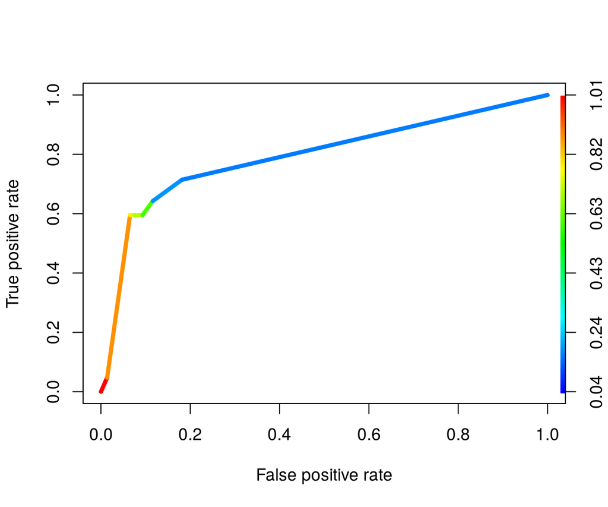

```r
plot(perfROCR, colorize = TRUE, lwd = 4)
```

The best cutoff to select is entirely dependent on the costs assigned by the decision maker to false positives and true positives.  
However, we do favor cutoffs that give us a **high sensitivity**, *i.e.* we want to identify a large number of the responsive documents.

Therefore a choice that might look promising could be in the part of the curve where it becomes flatter (going towards the right), where we have a **true positive rate of around 70%** (meaning that we’re getting about 70% of all the responsive documents), and a **false positive rate of about 20%** (meaning that we are making mistakes and accidentally identifying as responsive 20% of the non-responsive documents.)

Since, typically, the vast majority of documents are non-responsive, operating at this cutoff would result in a large decrease in the amount of manual effort needed in the *eDiscovery* process.

From the blue color of the plot at this particular location we can infer that we are looking at a threshold around maybe 0.15 or so, significantly lower than 0.5, which is definitely what we would expect since we favor false positives to false negatives.

### *Area Under the Curve* (AUC)

```r
auc_CART <- as.numeric(performance(predROCR, "auc")@y.values)
```

The AUC of the *CART* models is **0.7936**, which means that our model can differentiate between a randomly selected responsive and non-responsive document about **79.4%** of the time.